# homework_06_Hua Ji

## CMPINF 2120: Homework 06

## Assigned: Tuesday of Week 06 at 11:00PM

## DUE: Tuesday of Week 07 at 11:59PM

This assignment is shorter than the other assignments because you must also complete Exam 1 this week. Therefore, this assignment is hyperfocused on the essential aspects of working with categorical inputs. You will use two synthetic data sets created specifically for this assignment. The data do not need to preprocessed in order for you to focus on the primary aspects of working with categorical inputs.

The assignment is divided into two main sections. In the first section, the data you will work with involves a single categorical input. You will gain experience comparing dummy variables with one-hot encodings by studying their features and coefficient interpretations when used for linear models. The second section involves a data set that includes categorical and continuous inputs. You will therefore gain experience with **mixed input** situations by fitting models with additive and interaction features derived from the two inputs.

You may add as many code and markdown cells as you see fit to answer the questions.

### Collaborators

Type the names of other students you worked with here.

## Problem 00

Let's import all required modules and functions for this assignment upfront.

### 0a)

Import the "big 4" data analysis modules of NumPy, Pandas, matplotlib pyplot, and Seaborn. You **must** use their common aliases.

#### 0a) - SOLUTION

```python
import numpy as np
import pandas as pd
import matplotlib.pyplot as plt

import seaborn as sns
```

### 0b)

You will fit linear models via `statsmodels` and create feature arrays using `dmatrices()`.

Import the statsmodels formula interface using its common alias. Import the `dmatrices()` function from the appropriate module.

#### 0b) - SOLUTION

```python
from patsy import dmatrices
import statsmodels.formula.api as smf
```

## Problem 01

The first synthetic data involves a single **categorical input**. One input is used to support visualization and to easily display results to the screen. Even though the data may be fake, this style of problem is quite common in many fields. As an example, the last assignment introduced you to the UCI Machine Learning Repository Concrete Data Set. The goal of that application is to predict the strength of concrete based on various components that create the concrete mixture. The strength was measured from samples produced in experiments and trials. The strength might have been measured in different labs by different people at different times. The measurements must be conducted in a consistent manner with similar equipment or there will be no way to use all measurements to train *machine learning* models! The models are only as good as the data that train them! If you cannot trust the measurements then you cannot trust the models!

Why does this matter? Laboratories are routinely involved in repeability studies. Different labs are provided with samples of material. The labs measure the material using their **standard operating procedures**. The results are then shared and the measurements compared across the labs. The goal is to identify if the different labs produce measurements that are **within the margin of error** of each other. Data from these studies can be organized where the lab is a **categorical input** and the measurement of interest is the **response**. Therefore, the lab repeability study can be viewed as a **linear model** for regression with a single categorical input and single continuous response!

You will use the "fake" lab repeability study to practice working with categorical inputs for linear models.

### 1a)

The synthetic data file name is assigned to the `probA_path` object in the cell below. The file name assumes that you have downloaded the `hw06_probA.csv` file into the same working directory as this notebook.

```python
probA_path = 'hw06_probA.csv'
```

The data set consists of 2 columns. The `x` column is the single categorical input (the lab name) and the `y` column is the single numeric output.

Read in the data using the appropriate Pandas function and assign the result to the `dfA` object. Display the `.info()` method to confirm the data have been read in correctly.

#### 1a) - SOLUTION

```python
dfA=pd.read_csv(probA_path)
```

```python
dfA.info()
```

```
<class 'pandas.core.frame.DataFrame'>
RangeIndex: 84 entries, 0 to 83
Data columns (total 2 columns):
 #   Column  Non-Null Count  Dtype
---  ------  --------------  -----
 0   x       84 non-null     object
 1   y       84 non-null     float64
dtypes: float64(1), object(1)
memory usage: 1.4+ KB
```

### 1b)

You will not perform a detailed EDA for this assignment. Instead, you will quickly explore the data using visualizations that support linear models with categorical inputs.

Begin your exploration by displaying the counts of the categorical input via a bar chart in Seaborn.

Are the categories of the categorical input balanced?

#### 1b) - SOLUTION

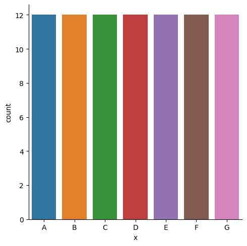

```python
sns.catplot(dfA, x='x',kind='count')
plt.show()
```

Yes, the categories of the categorical input are balanced.

### 1c)

Next, let's explore the relationship between the continuous output and the categorical input. Visualize the summary statistics of the continuous output given the categories of the categorical input using a boxplot. You must create the boxplot in Seaborn.

Do any labs appear different from the others?

#### 1c) - SOLUTION

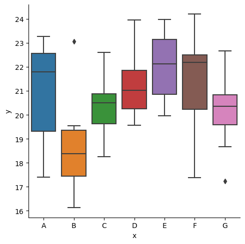

```python
sns.catplot(dfA, x='x', y='y', kind='box')
plt.show()
```

Yes, it seems lab B's result is quite different from other labs.

### 1d)

The boxplot summaries the conditional distribution, but you have learned that linear models predict **averages**. Therefore, it is critical to explore how the **average** output changes across categories of the categorical input.

Create a point plot in Seaborn to visualize the average output for each category of the continuous input.

Do any labs appear to yield different measurements on average compared to the others?

#### 1d) - SOLUTION

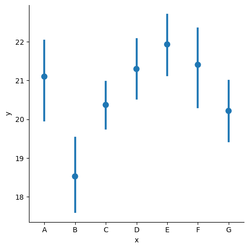

```python
sns.catplot(dfA, x='x', y='y', kind='point',join=False)
plt.show()
```

Yes, lab B's result almost has no overlap with those of the other labs.

## Problem 02

You have explored the relationships between the output and the categorical input. However, before fitting models to quantify your results it is important to first check the **features** derived from the categorical input. You will use `dmatrices()` to generate the **design matrix** or **input feature array**. You first create **dummy variables** and then you will create **one hot encodings**.

### 2a)

You must generate the output and input feature arrays based on **dummy variables** derived from the categorical input from `dfA` using `dmatrices()` and the formula interface. The output array must be assigned to the `yA_df_dummy` object and the input feature array must be assigned to the `XA_df_dummy` object. You **must** return Pandas DataFrames from `dmatrices()`.

Display the `.head()` of each Pandas DataFrame to the screen.

*HINT*: You can think of the dummy variables as a linear model with a linear relationship when typing the formula.

#### 2a) - SOLUTION

```python
yA_df_dummy, XA_df_dummy= dmatrices('y~x',data=dfA, return_type='dataframe')
```

```python
yA_df_dummy.head()
```

|  | y |
| --- | --- |
| 0 | 23.022679 |
| 1 | 19.432844 |
| 2 | 22.900301 |
| 3 | 18.680001 |
| 4 | 18.982493 |

```python
XA_df_dummy.head()
```

|  | Intercept | x[T.B] | x[T.C] | x[T.D] | x[T.E] | x[T.F] | x[T.G] |
| --- | --- | --- | --- | --- | --- | --- | --- |
| 0 | 1.0 | 0.0 | 0.0 | 0.0 | 0.0 | 0.0 | 0.0 |
| 1 | 1.0 | 0.0 | 0.0 | 0.0 | 0.0 | 0.0 | 0.0 |
| 2 | 1.0 | 0.0 | 0.0 | 0.0 | 0.0 | 0.0 | 0.0 |
| 3 | 1.0 | 0.0 | 0.0 | 0.0 | 0.0 | 0.0 | 0.0 |
| 4 | 1.0 | 0.0 | 0.0 | 0.0 | 0.0 | 0.0 | 0.0 |

### 2b)

The problem involves a single input. How many columns are within the **design matrix** or **input feature array**, `XA_df_dummy`? Display the number of unique values for each column to the screen.

#### 2b) - SOLUTION

```python
len(XA_df_dummy.columns)
```

```
7
```

There are 7 columns are within the design matrix.

```python
XA_df_dummy.nunique()
```

```
Intercept    1
x[T.B]       2
x[T.C]       2
x[T.D]       2
x[T.E]       2
x[T.F]       2
x[T.G]       2
dtype: int64
```

### 2c)

Next, you must generate the output and input feature arrays based on **one-hot encodings** derived from the categorical input from `dfA` using `dmatrices()` and the formula interface. The output array must be assigned to the `yA_df_onehot` object and the input feature array must be assigned to the `XA_df_onehot` object. You **must** return Pandas DataFrames from `dmatrices()`.

Display the `.head()` of each Pandas DataFrame to the screen.

*HINT*: You must change the formula to create the one-hots...

#### 2c) - SOLUTION

```python
yA_df_onehot,XA_df_onehot=dmatrices('y~x-1', data=dfA, return_type='dataframe')
```

```python
yA_df_onehot.head()
```

|  | y |
| --- | --- |
| 0 | 23.022679 |
| 1 | 19.432844 |
| 2 | 22.900301 |
| 3 | 18.680001 |
| 4 | 18.982493 |

```python
XA_df_onehot.head()
```

|  | x[A] | x[B] | x[C] | x[D] | x[E] | x[F] | x[G] |
| --- | --- | --- | --- | --- | --- | --- | --- |
| 0 | 1.0 | 0.0 | 0.0 | 0.0 | 0.0 | 0.0 | 0.0 |
| 1 | 1.0 | 0.0 | 0.0 | 0.0 | 0.0 | 0.0 | 0.0 |
| 2 | 1.0 | 0.0 | 0.0 | 0.0 | 0.0 | 0.0 | 0.0 |
| 3 | 1.0 | 0.0 | 0.0 | 0.0 | 0.0 | 0.0 | 0.0 |
| 4 | 1.0 | 0.0 | 0.0 | 0.0 | 0.0 | 0.0 | 0.0 |

### 2d)

The problem involves a single input. How many columns are within the design matrix or input feature array, `XA_df_onehot`? Display the number of unique values for each column to the screen.

#### 2d) - SOLUTION

```python
len(XA_df_onehot.columns)
```

```
7
```

There are seven columns are within the design matrix.

```python
XA_df_onehot.nunique()
```

```
x[A]    2
x[B]    2
x[C]    2
x[D]    2
x[E]    2
x[F]    2
x[G]    2
dtype: int64
```

### 2e)

What is the difference between the **design matrix** or **input feature array** between the dummy variable approach and the one-hot encoding approach?

#### 2e) - SOLUTION

The difference is that in the dummy variable approach, the intercept is the reference category that other dummies are relative to. In the onehot encoding approach there are no intercept or reference category.

## Problem 03

Now that you have examined the features associated with the two approaches, it is time to fit linear models! Your results will be used to identify differences between the labs. But, remember your previous exploratory visualizations already gave you a good idea about the differences!

### 3a)

Fit the linear model with **dummy variables** derived from the categorical input using `statsmodels`. Assign the result to `fit_A_dummy`. Display the coefficient estimates to the screen.

*HINT*: You can think of the dummy variables as a linear model with a linear relationship when typing the formula.

#### 3a) - SOLUTION

```python
fit_A_dummy=smf.ols(formula='y~x', data=dfA).fit()
```

```python
fit_A_dummy.params
```

```
Intercept    21.101679
x[T.B]       -2.574258
x[T.C]       -0.730793
x[T.D]        0.196509
x[T.E]        0.829957
x[T.F]        0.304641
x[T.G]       -0.885001
dtype: float64
```

### 3b)

The problem involves a single input. How many coefficients are estimated for the `fit_A_dummy` model?

The number of coefficients is equal to **what** aspect of the **design matrix** or **input feature array**, `XA_df_dummy`, that you examined previously in 2b)?

#### 3b) - SOLUTION

```python
len(fit_A_dummy.params)
```

```
7
```

Seven coefficients are estimated for the fit_A_dummy model.

The number of coefficients is equal ot the number of columns of the design matric.

### 3c)

You fit the model with dummy variables, and now want to identify differences between the labs. You decide to use the coefficient p-values to identify **statistically significant** features in the model.

Use the **conventional statistical significance** threshold and the coefficient p-values to identify which coefficients are statistically significant.

You do not need to visualize the coefficient plot for this result (though you are welcome to do so if you would like!). This question is focused on working with p-values.

#### 3c) - SOLUTION

```python
fit_A_dummy.conf_int()
```

|  | 0 | 1 |
| --- | --- | --- |
| Intercept | 20.170844 | 22.032515 |
| x[T.B] | -3.890658 | -1.257858 |
| x[T.C] | -2.047193 | 0.585607 |
| x[T.D] | -1.119891 | 1.512909 |
| x[T.E] | -0.486443 | 2.146357 |
| x[T.F] | -1.011759 | 1.621042 |
| x[T.G] | -2.201401 | 0.431399 |

```python
fit_A_dummy.pvalues<0.05
```

```
Intercept     True
x[T.B]        True
x[T.C]       False
x[T.D]       False
x[T.E]       False
x[T.F]       False
x[T.G]       False
dtype: bool
```

The pvalues tells us that only the intercept and x[T.B] are statistically significant. The confidence interval also tells us that only these two values are not cross 0 values line.

### 3d)

Now that you worked with the dummy variables, it's time to fit models with one-hots! Fit the linear model with **one-hot encodings** derived from the categorical input using `statsmodels`. Assign the result to `fit_A_onehot`. Display the coefficient estimates to the screen.

*HINT*: You must change the formula to create the one-hots...

#### 3d) - SOLUTION

```python
fit_A_onehot=smf.ols('y~x-1', data=dfA).fit()
```

```python
fit_A_onehot.params
```

```
x[A]    21.101679
x[B]    18.527421
x[C]    20.370887
x[D]    21.298188
x[E]    21.931637
x[F]    21.406321
x[G]    20.216679
dtype: float64
```

### 3e)

The problem involves a single input. How many coefficients are estimated for the `fit_A_onehot` model?

The number of coefficients is equal to **what** aspect of the **design matrix** or **input feature array**, `XA_df_onehot`, that you examined previously in 2c)?

#### 3e) - SOLUTION

```python
len(fit_A_onehot.params)
```

```
7
```

Seven coefficients are estimated for the fit_A_onehot model.

The number of coefficient is equal to the number of columns(features) of the design matrix.

### 3f)

You fit the model with one-hot encodings, and now want to identify differences between the labs. You decide to use the coefficient p-values to identify **statistically significant** features in the model.

Use the **conventional statistical significance** threshold and the coefficient p-values to identify which coefficients are statistically significant.

You do not need to visualize the coefficient plot for this result (though you are welcome to do so if you would like!). This question is focused on working with p-values.

#### 3f) - SOLUTION

```python
fit_A_onehot.pvalues<0.05
```

```
x[A]    True
x[B]    True
x[C]    True
x[D]    True
x[E]    True
x[F]    True
x[G]    True
dtype: bool
```

```python
fit_A_onehot.conf_int()
```

|  | 0 | 1 |
| --- | --- | --- |
| x[A] | 20.170844 | 22.032515 |
| x[B] | 17.596586 | 19.458257 |
| x[C] | 19.440051 | 21.301722 |
| x[D] | 20.367353 | 22.229024 |
| x[E] | 21.000801 | 22.862472 |
| x[F] | 20.475485 | 22.337156 |
| x[G] | 19.285843 | 21.147514 |

Use OneHot method all the coefficients are statistically significant.

### 3g)

You compared the one-hot encoding p-values to the conventional threshold in the previous problem. That is the common strategy that most references online say to identify statistically significant features. How could it be wrong?

Do the one-hot encoding p-values identify the statistically significant features that are "different"? Do the dummy variable p-values identify the statistically significant features that are "different"?

Essentially, this question is asking which approach, dummy vs one-hot, yield p-value results consistent with your initial set of explorations?

Type your response in a markdown cell below.

#### 3g) - SOLUTION

The one-hot encoding p-values do not identify the statistically significant features that are different. The dummy valirable p-values identifies the statistically significant features that are different.

so the dummy approach yield p-value results consist with the initial set of explorations.

## Problem 04

The previous problems involved a single categorical input. However, you will commonly work with **mixed inputs** that involve categorical and continuous inputs. The next set of problems give you experience working with features derived from **mixed inputs**.

### 4a)

The synthetic data file name is assigned to the `probB_path` object in the cell below. The file name assumes that you have downloaded the `hw06_probB.csv` file into the same working directory as this notebook.

```python
probB_path = 'hw06_probB.csv'
```

The data set consists of 3 columns. The input columns start with the letter `'x'` and the output column is named `y`.

Read in the data using the appropriate Pandas function and assign the result to the `dfB` object. Display the `.info()` method to confirm the data have been read in correctly.

Which input corresponds to the categorical input?

#### 4a) - SOLUTION

```python
dfB=pd.read_csv(probB_path)
```

```python
dfB.info()
```

```
<class 'pandas.core.frame.DataFrame'>
RangeIndex: 151 entries, 0 to 150
Data columns (total 3 columns):
 #   Column  Non-Null Count  Dtype
---  ------  --------------  -----
 0   x1      151 non-null    object
 1   x2      151 non-null    float64
 2   y       151 non-null    float64
dtypes: float64(2), object(1)
memory usage: 3.7+ KB
```

x1 is the categorical input.

### 4b)

As with the previous data set, you will not perform a detailed EDA for this assignment. Instead, you will quickly explore the data using visualizations that support linear models with mixed inputs.

Begin your exploration by displaying the counts of the categorical input via a bar chart in Seaborn.

Are the categories of the categorical input balanced?

#### 4b) - SOLUTION

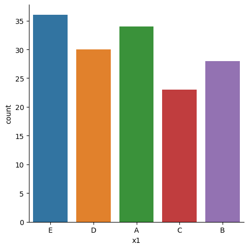

```python
sns.catplot(data=dfB, x='x1', kind='count')
plt.show()
```

```python
dfB.x1.value_counts(normalize=True)
```

```
x1
E    0.238411
A    0.225166
D    0.198675
B    0.185430
C    0.152318
Name: proportion, dtype: float64
```

Since the difference between the categorical inputs are not that big, we can say it is roughly balanced.

### 4c)

Next, let's explore the relationship between the continuous output and the categorical input. Visualize the summary statistics of the continuous output given the categories of the categorical input using a boxplot. You must create the boxplot in Seaborn.

Do the output summary statistics vary across the categories?

#### 4c) - SOLUTION

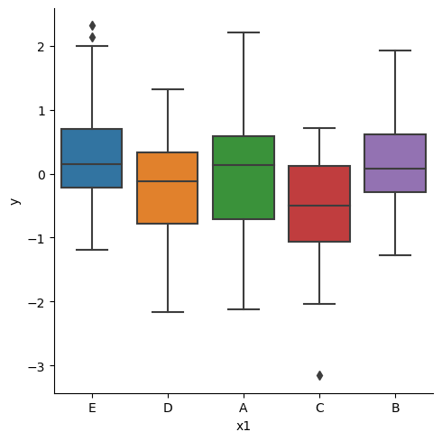

```python
sns.catplot(data=dfB, x='x1', y='y',kind='box')
plt.show()
```

The output summary statistics didn't vary that much across the categories

### 4d)

The boxplot summarizes the conditional distribution, but you have learned that linear models predict **averages**. Therefore, it is critical to explore how the **average** output changes across categories of the categorical input.

Create a point plot in Seaborn to visualize the average output for each category of the continuous input.

Does the output appear to be different on average across the categories?

#### 4d) - SOLUTION

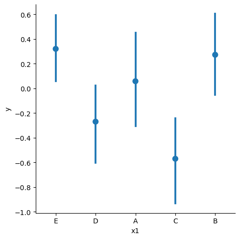

```python
sns.catplot(dfB, x='x1', y='y', kind='point', join=False)
plt.show()
```

Since all of them are overlap with each other, so it's hard to say that there is difference among all of them. But you can say the average of C is different from that of B and E.

### 4e)

You explored the output to categorical input relationship, but this problem also involves a numeric input! The output to numeric input relationship must also be explored!

Create a scatter plot in Seaborn to visualize the relationship between the output and numeric input.

Can you easily see a relationship between them in the figure?

#### 4e) - SOLUTION

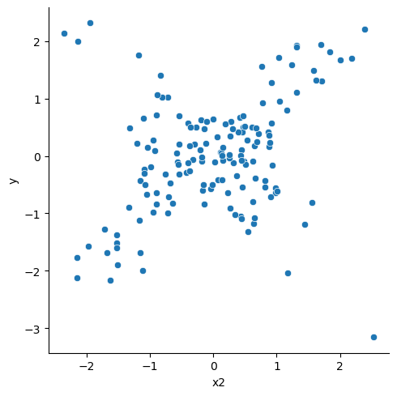

```python
sns.relplot(dfB, x='x2', y='y')
plt.show()
```

it is hard to say what kind of relationship between x2 and y

### 4f)

Trend plots can help us see "signals through the noise" by including regression lines (best fit lines) on top of the scatter plots.

Create a trend plot in Seaborn to display a "smoothed" linear relationship between the output and numeric input.

Does there appear to be a relationship between the two variables?

#### 4f) - SOLUTION

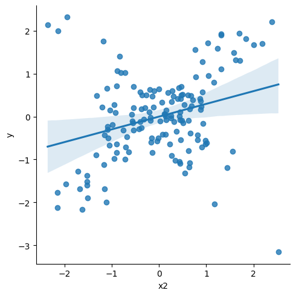

```python
sns.lmplot(dfB, x='x2', y='y')
plt.show()
```

No, it's hard to find out the relationship between the variables.

### 4g)

Trend plots can be grouped by categorical variables in Seaborn. One approach is to color the markers and the trend line based on categorical variables.

Create a trend plot in Seaborn between the output and numeric input colored by the categorical input.

Is the relationship between the output and numeric input consistent across the groups?

#### 4g) - SOLUTION

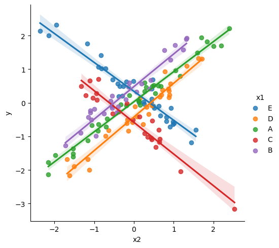

```python
sns.lmplot(dfB, x='x2', y='y', hue='x1')
plt.show()
```

No, although all the relationship between the output and numeric input are linear relationship. A,D,B increase with the increase of inputs. and in C,E the output decrease with the increase of inputs.

### 4h)

Which types of features do you think will be required to properly model the output to input relationship based on the previous set of figures?

Type your response in a markdown cell below.

#### 4h) - SOLUTION

Both x1 and x2 will be requrired to properly model the output to input relationship.

## Problem 05

As with the previous example, after exploring the data the next step is to examine features that you will consider in your models.

You will only work with dummy variables derived from the categorical input in this problem.

### 5a)

The previous example with `dfA` did not require you to examine the features associated with an INTERCEPT-ONLY model. However, you should NEVER forget about this critically important model even though it is very simple! Therefore, let's begin with the simplest possible linear model, the INTERCEPT-ONLY or unknown constant average model!

You must generate the output and input feature arrays for an INTERCEPT-ONLY model for `dfB` using `dmatrices()` and the formula interface. The output array must be assigned to the `yB_df_0` object and the input feature array must be assigned to the `XB_df_0` object. You **must** return Pandas DataFrames from `dmatrices()`.

Display the `.head()` of each Pandas DataFrame to the screen.

#### 5a) - SOLUTION

```python
yB_df_0,XB_df_0 = dmatrices('y~1', data =dfB, return_type='dataframe')
```

```python
yB_df_0.head()
```

|  | y |
| --- | --- |
| 0 | -0.091771 |
| 1 | 1.027927 |
| 2 | 1.026627 |
| 3 | -0.572029 |
| 4 | -0.156198 |

```python
XB_df_0.head()
```

|  | Intercept |
| --- | --- |
| 0 | 1.0 |
| 1 | 1.0 |
| 2 | 1.0 |
| 3 | 1.0 |
| 4 | 1.0 |

### 5b)

How many features are associated with the INTERCEPT-ONLY model?

#### 5b) - SOLUTION

```python
len(XB_df_0.columns)
```

```
1
```

### 5c)

Next, let's examine the features associated with the dummy variables derived from the categorical input. Thus, you will only consider the categorical input.

You must generate the output and input feature arrays based on **dummy variables** derived from the categorical input from `dfB` using `dmatrices()` and the formula interface. The output array must be assigned to the `yB_df_1dummy` object and the input feature array must be assigned to the `XB_df_1dummy` object. You **must** return Pandas DataFrames from `dmatrices()`.

Display the `.head()` of each Pandas DataFrame to the screen.

*HINT*: You can think of the dummy variables as a linear model with a linear relationship when typing the formula.

#### 5c) - SOLUTION

```python
yB_df_1dummy, XB_df_1dummy=dmatrices('y~x1',data=dfB, return_type='dataframe')
```

```python
yB_df_1dummy.head()
```

|  | y |
| --- | --- |
| 0 | -0.091771 |
| 1 | 1.027927 |
| 2 | 1.026627 |
| 3 | -0.572029 |
| 4 | -0.156198 |

```python
XB_df_1dummy.head()
```

|  | Intercept | x1[T.B] | x1[T.C] | x1[T.D] | x1[T.E] |
| --- | --- | --- | --- | --- | --- |
| 0 | 1.0 | 0.0 | 0.0 | 0.0 | 1.0 |
| 1 | 1.0 | 0.0 | 0.0 | 0.0 | 1.0 |
| 2 | 1.0 | 0.0 | 0.0 | 0.0 | 1.0 |
| 3 | 1.0 | 0.0 | 0.0 | 1.0 | 0.0 |
| 4 | 1.0 | 0.0 | 0.0 | 0.0 | 1.0 |

### 5d)

You included a SINGLE categorical input in `XB_df_1dummy`. How many columns are within the **design matrix** or **input feature array**, `XB_df_1dummy`?

#### 5d) - SOLUTION

```python
len(XB_df_1dummy.columns)
```

```
5
```

5 columns are within the design matrix of XB_df_1dummy.

### 5e)

Next, let's examine the features associated with a model that linearly relates the numeric input to the output. This model will therefore not consider the categorical input. You are therefore generating the design matrix associated with the classic "best fit line".

The output array must be assigned to the `yB_df_1num` object and the input feature array must be assigned to the `XB_df_1num` object. You must return Pandas DataFrames from `dmatrices()`.

Display the `.head()` of the `XB_df_1num` DataFrame to the screen.

#### 5e) - SOLUTION

```python
yB_df_1num,XB_df_1num=dmatrices('y~x2',data=dfB, return_type='dataframe')
```

```python
XB_df_1num.head()
```

|  | Intercept | x2 |
| --- | --- | --- |
| 0 | 1.0 | 0.481871 |
| 1 | 1.0 | -0.718793 |
| 2 | 1.0 | -0.814340 |
| 3 | 1.0 | -0.044182 |
| 4 | 1.0 | 0.932711 |

### 5f)

You included a SINGLE numeric input in `XB_df_1num`. How many columns are within the **design matrix** or **input feature array**, `XB_df_1num`?

#### 5f) - SOLUTION

```python
len(XB_df_1num.columns)
```

```
2
```

2 columns are within the design matrix.

### 5g)

Next, let's create the features associated with a **mixed input** model! This model will involve **linear additive features** associated with the two inputs. Thus, you are "adding" the effect of the categorical input to the numeric input.

The output array must be assigned to the `yB_df_2add` object and the input feature array must be assigned to the `XB_df_2add` object. You must return Pandas DataFrames from `dmatrices()`.

Display the `.head()` of the `XB_df_2add` DataFrame to the screen.

#### 5g) - SOLUTION

```python
yB_df_2add, XB_df_2add =dmatrices('y~x1+x2', data=dfB, return_type='dataframe')
```

```python
XB_df_2add.head()
```

|  | Intercept | x1[T.B] | x1[T.C] | x1[T.D] | x1[T.E] | x2 |
| --- | --- | --- | --- | --- | --- | --- |
| 0 | 1.0 | 0.0 | 0.0 | 0.0 | 1.0 | 0.481871 |
| 1 | 1.0 | 0.0 | 0.0 | 0.0 | 1.0 | -0.718793 |
| 2 | 1.0 | 0.0 | 0.0 | 0.0 | 1.0 | -0.814340 |
| 3 | 1.0 | 0.0 | 0.0 | 1.0 | 0.0 | -0.044182 |
| 4 | 1.0 | 0.0 | 0.0 | 0.0 | 1.0 | 0.932711 |

### 5h)

You included TWO inputs in `XB_df_2add`. How many columns are within the **design matrix** or **input feature array**, `XB_df_2add`?

#### 5h) - SOLUTION

```python
len(XB_df_2add.columns)
```

```
6
```

Six columns are within the design matrix of XB_df_2add

### 5i)

Lastly, let's examine the features associated with **interacting** the categorical and numeric inputs. The **main** effect and **interaction** features **must** be included.

The output array must be assigned to the `yB_df_2int` object and the input feature array must be assigned to the `XB_df_2int` object. You must return Pandas DataFrames from `dmatrices()`.

Display the `.head()` of the `XB_df_2int` DataFrame to the screen.

#### 5i) - SOLUTION

```python
yB_df_2int,XB_df_2int=dmatrices('y~x1*x2', data =dfB, return_type='dataframe')
```

```python
XB_df_2int.head()
```

|  | Intercept | x1[T.B] | x1[T.C] | x1[T.D] | x1[T.E] | x2 | x1[T.B]:x2 | x1[T.C]:x2 | x1[T.D]:x2 | x1[T.E]:x2 |
| --- | --- | --- | --- | --- | --- | --- | --- | --- | --- | --- |
| 0 | 1.0 | 0.0 | 0.0 | 0.0 | 1.0 | 0.481871 | 0.0 | 0.0 | 0.000000 | 0.481871 |
| 1 | 1.0 | 0.0 | 0.0 | 0.0 | 1.0 | -0.718793 | -0.0 | -0.0 | -0.000000 | -0.718793 |
| 2 | 1.0 | 0.0 | 0.0 | 0.0 | 1.0 | -0.814340 | -0.0 | -0.0 | -0.000000 | -0.814340 |
| 3 | 1.0 | 0.0 | 0.0 | 1.0 | 0.0 | -0.044182 | -0.0 | -0.0 | -0.044182 | -0.000000 |
| 4 | 1.0 | 0.0 | 0.0 | 0.0 | 1.0 | 0.932711 | 0.0 | 0.0 | 0.000000 | 0.932711 |

### 5j)

You included TWO inputs in `XB_df_2int`. How many columns are within the **design matrix** or **input feature array**, `XB_df_2int`?

#### 5j) - SOLUTION

```python
len(XB_df_2int.columns)
```

```
10
```

Ten columns are within the design matrix or input feature array.

### 5k)

**Why** does the design matrix that include the interaction, `XB_df_2int`, require more columns compared to the other design matrices you examined? Why do the exploratory figures support the use of these additional features?

#### 5k) - SOLUTION

Because there are interaction terms between the inputs except the main effects.

## Problem 06

You will now fit linear models to predict the output based on the inputs!

### 6a)

Fit the INTERCEPT-ONLY model using the formula interface and assign the result to the `fit_B_0` object.

Display the coefficient estimate to the screen.

#### 6a) - SOLUTION

```python
fit_B_0=smf.ols(formula='y~1', data=dfB).fit()
```

```python
fit_B_0.params
```

```
Intercept    1.951564e-17
dtype: float64
```

### 6b)

Next, fit a model that includes **dummy variables** derived from the categorical input. You will **not** include the numeric input in this model. Assign the fitted model to the `fit_B_1dummy` object.

Which features are statistically significant using the **conventional threshold** for statistical significance?

#### 6b) - SOLUTION

```python
fit_B_1dummy=smf.ols(formula='y~x1', data =dfB).fit()
```

```python
fit_B_1dummy.params
```

```
Intercept    0.058590
x1[T.B]      0.214345
x1[T.C]     -0.628442
x1[T.D]     -0.327792
x1[T.E]      0.262201
dtype: float64
```

```python
fit_B_1dummy.pvalues<0.05
```

```
Intercept    False
x1[T.B]      False
x1[T.C]       True
x1[T.D]      False
x1[T.E]      False
dtype: bool
```

```python
fit_B_1dummy.conf_int()
```

|  | 0 | 1 |
| --- | --- | --- |
| Intercept | -0.266668 | 0.383847 |
| x1[T.B] | -0.269654 | 0.698343 |
| x1[T.C] | -1.140478 | -0.116406 |
| x1[T.D] | -0.802861 | 0.147277 |
| x1[T.E] | -0.191349 | 0.715751 |

according to pvalues, the categories C in input x1 is statistically significant

### 6c)

Next, fit a model that includes a single numeric input linearly related to the output. You will **not** include the categorical input in this model. Assign the fitted model to the `fit_B_1num` object.

Which features are statistically significant using the **conventional threshold** for statistical significance?

#### 6c) - SOLUTION

```python
fit_B_1num=smf.ols(formula='y~x2', data = dfB).fit()
```

```python
fit_B_1num.pvalues<0.05
```

```
Intercept    False
x2            True
dtype: bool
```

x2 is statistically significant according to the conventional threshold.

### 6d)

Next, fit a model with **mixed inputs** by including **linear additive features** for **both** inputs. Assign the fitted model to the `fit_B_2add` object.

Which features are statistically significant using the **conventional threshold** for statistical significance?

#### 6d) - SOLUTION

```python
fit_B_2add=smf.ols(formula='y~x1+x2', data=dfB).fit()
```

```python
fit_B_2add.pvalues<0.05
```

```
Intercept    False
x1[T.B]      False
x1[T.C]       True
x1[T.D]      False
x1[T.E]      False
x2            True
dtype: bool
```

Feature x2 and category C in x1 are statistically significant.

### 6e)

Lastly, fit a model that **interacts** the categorical and numeric inputs. Assign the fitted model to the `fit_B_2int` object. The model must include the **main** effects and the **interaction** features.

Which features are statistically significant using the **conventional threshold** for statistical significance?

#### 6e) - SOLUTION

```python
fit_B_2int=smf.ols(formula='y~x1*x2', data=dfB).fit()
```

```python
fit_B_2int.pvalues<0.05
```

```
Intercept     False
x1[T.B]        True
x1[T.C]        True
x1[T.D]        True
x1[T.E]        True
x2             True
x1[T.B]:x2    False
x1[T.C]:x2     True
x1[T.D]:x2    False
x1[T.E]:x2     True
dtype: bool
```

Features X2, categories B,C,D,E from input x1 and interacton features x1[T,C]:x2, x1[T.E]:x2 are statistically significant.

## Problem 07

You will conclude this assignment by **visualizing** the predictive trends associated with the 5 models you fit in the previous problem. Lecture examples the last two weeks stressed the importance of visualizing predictive uncertainty via CONFIDENCE and PREDICTION INTERVALS. However, let's focus on the PREDICTIVE TRENDS for simplicity in this assignment. This allows you to use Seaborn to easily visualize the predictive trends due to changes in **both** inputs by coloring the lines based on the categorical input.

This problem focuses on making the predictions. The next problem visualizes those predictions.

### 7a)

A new data set must be defined before predictions can be made. Compared to the previous assignment, the prediction or visualization data set involves 2 inputs. Therefore, you must define **combinations** of both inputs to successfully visualize the predictions from the models fit in Problem 6).

Create a DataFrame, `input_B_viz`, that consists of a two columns. One column must be named the same as the categorical input in `dfB` and the other column must be named the same as the numeric input in `dfB`. All categories associated with the categorical input must be included. The numeric column must consist of 101 evenly spaced points between the numeric input's training set lower and upper bounds.

Display the number of unique values associated with each column in `input_B_viz`.

#### 7a) - SOLUTION

```python
input_B_viz=pd.DataFrame([(x1,x2)for x2 in np.linspace(dfB.x2.min(), dfB.x2.max(), num=101)
                    for x1 in dfB.x1.unique().tolist()],
                    columns=['x1','x2'])
```

```python
input_B_viz.nunique()
```

```
x1      5
x2    101
dtype: int64
```

### 7b)

Before making predictions, let's be safe and make a deep or hard copy of the `input_B_viz` DataFrame.

Assign the hard copy to the `dfB_viz` DataFrame.

Display the `.head()` of the `dfB_viz` DataFrame to the screen.

#### 7b) - SOLUTION

```python
dfB_viz=input_B_viz.copy()
```

```python
dfB_viz.head()
```

|  | x1 | x2 |
| --- | --- | --- |
| 0 | E | -2.359619 |
| 1 | D | -2.359619 |
| 2 | A | -2.359619 |
| 3 | C | -2.359619 |
| 4 | B | -2.359619 |

### 7c)

Assign a new column to the `dfB_viz` DataFrame that corresponds to the predictions from the INTERCEPT-ONLY model, `fit_B_0`.

The new column must be named `pred_0`.

Display the `.head()` of `dfB_viz` to the screen.

#### 7c) - SOLUTION

```python
dfB_viz['pred_0'] =fit_B_0.predict(dfB_viz)
```

```python
dfB_viz.head()
```

|  | x1 | x2 | pred_0 |
| --- | --- | --- | --- |
| 0 | E | -2.359619 | 1.951564e-17 |
| 1 | D | -2.359619 | 1.951564e-17 |
| 2 | A | -2.359619 | 1.951564e-17 |
| 3 | C | -2.359619 | 1.951564e-17 |
| 4 | B | -2.359619 | 1.951564e-17 |

### 7d)

Assign a new column to the `dfB_viz` DataFrame that corresponds to the predictions from the model with the single categorical input, `fit_B_1dummy`.

The new column must be named `pred_1dummy`.

Display the `.head()` of `dfB_viz` to the screen.

#### 7d) - SOLUTION

```python
dfB_viz['pred_1dummy'] = fit_B_1dummy.predict(dfB_viz)
```

```python
dfB_viz.head()
```

|  | x1 | x2 | pred_0 | pred_1dummy |
| --- | --- | --- | --- | --- |
| 0 | E | -2.359619 | 1.951564e-17 | 0.320791 |
| 1 | D | -2.359619 | 1.951564e-17 | -0.269203 |
| 2 | A | -2.359619 | 1.951564e-17 | 0.058590 |
| 3 | C | -2.359619 | 1.951564e-17 | -0.569852 |
| 4 | B | -2.359619 | 1.951564e-17 | 0.272935 |

### 7e)

Assign a new column to the `dfB_viz` DataFrame that corresponds to the predictions from the model with a single numeric input, `fit_B_1num`.

The new column must be named `pred_1num`.

Display the `.head()` of `dfB_viz` to the screen.

#### 7e) - SOLUTION

```python
dfB_viz['pred_1num']=fit_B_1num.predict(dfB_viz)
```

```python
dfB_viz.head()
```

|  | x1 | x2 | pred_0 | pred_1dummy | pred_1num |
| --- | --- | --- | --- | --- | --- |
| 0 | E | -2.359619 | 1.951564e-17 | 0.320791 | -0.700383 |
| 1 | D | -2.359619 | 1.951564e-17 | -0.269203 | -0.700383 |
| 2 | A | -2.359619 | 1.951564e-17 | 0.058590 | -0.700383 |
| 3 | C | -2.359619 | 1.951564e-17 | -0.569852 | -0.700383 |
| 4 | B | -2.359619 | 1.951564e-17 | 0.272935 | -0.700383 |

### 7f)

Assign a new column to the `dfB_viz` DataFrame that corresponds to the predictions from the **mixed input** model with **linear additive features** derived from **both** inputs, `fit_B_2add`.

The new column must be named `pred_2add`.

Display the `.head()` of `dfB_viz` to the screen.

#### 7f) - SOLUTION

```python
dfB_viz['pred_2add'] =fit_B_2add.predict(dfB_viz)
```

```python
dfB_viz.head()
```

|  | x1 | x2 | pred_0 | pred_1dummy | pred_1num | pred_2add |
| --- | --- | --- | --- | --- | --- | --- |
| 0 | E | -2.359619 | 1.951564e-17 | 0.320791 | -0.700383 | -0.434367 |
| 1 | D | -2.359619 | 1.951564e-17 | -0.269203 | -0.700383 | -1.065243 |
| 2 | A | -2.359619 | 1.951564e-17 | 0.058590 | -0.700383 | -0.698796 |
| 3 | C | -2.359619 | 1.951564e-17 | -0.569852 | -0.700383 | -1.313187 |
| 4 | B | -2.359619 | 1.951564e-17 | 0.272935 | -0.700383 | -0.406332 |

### 7g)

Assign a new column to the `dfB_viz` DataFrame that corresponds to the predictions from the **mixed input** model with **interactions** between **both** inputs, `fit_B_2int`.

The new column must be named `pred_2int`.

Display the `.head()` of `dfB_viz` to the screen.

#### 7g) - SOLUTION

```python
dfB_viz['pred_2int'] =fit_B_2int.predict(dfB_viz)
```

```python
dfB_viz.head()
```

|  | x1 | x2 | pred_0 | pred_1dummy | pred_1num | pred_2add | pred_2int |
| --- | --- | --- | --- | --- | --- | --- | --- |
| 0 | E | -2.359619 | 1.951564e-17 | 0.320791 | -0.700383 | -0.434367 | 2.374330 |
| 1 | D | -2.359619 | 1.951564e-17 | -0.269203 | -0.700383 | -1.065243 | -2.791182 |
| 2 | A | -2.359619 | 1.951564e-17 | 0.058590 | -0.700383 | -0.698796 | -2.083110 |
| 3 | C | -2.359619 | 1.951564e-17 | -0.569852 | -0.700383 | -1.313187 | 1.644305 |
| 4 | B | -2.359619 | 1.951564e-17 | 0.272935 | -0.700383 | -0.406332 | -1.809653 |

## Problem 08

You now have everything necessary to visualize the predictive trends! You will create the same type of figure for each model. You must visualize the predictive trends using a line chart created with Seaborn. The line charts must show the predictions on the y-axis and the numeric input on the x-axis. The line color must be associated with the categorical input. To be safe, be sure to set the `estimator` argument to `None` and the `units` argument to the categorical input.

### 8a)

Create the line chart in Seaborn to visualize the predictive trends associated with the INTERCEPT-ONLY model.

#### 8a) - SOLUTION

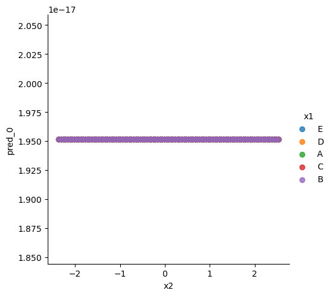

```python
sns.lmplot(data =dfB_viz,x='x2', y='pred_0', hue='x1')
plt.show()
```

### 8b)

Create the line chart in Seaborn to visualize the predictive trends associated with the model with a SINGLE categorical input.

#### 8b) - SOLUTION

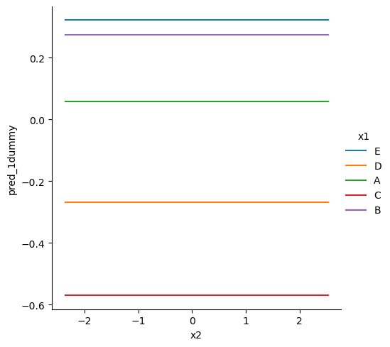

```python
sns.relplot(data=dfB_viz, x='x2', y='pred_1dummy', hue='x1', kind="line")
plt.show()
```

### 8c)

Create the line chart in Seaborn to visualize the predictive trends associated with the model with a SINGLE numeric input.

#### 8c) - SOLUTION

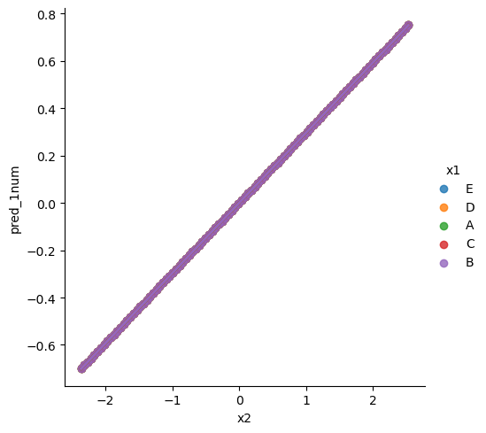

```python
sns.lmplot(data=dfB_viz, x='x2', y='pred_1num', hue='x1')
plt.show()
```

### 8d)

Create the line chart in Seaborn to visualize the predictive trends associated with the **mixed input** model with **linear additive features**.

#### 8d) - SOLUTION

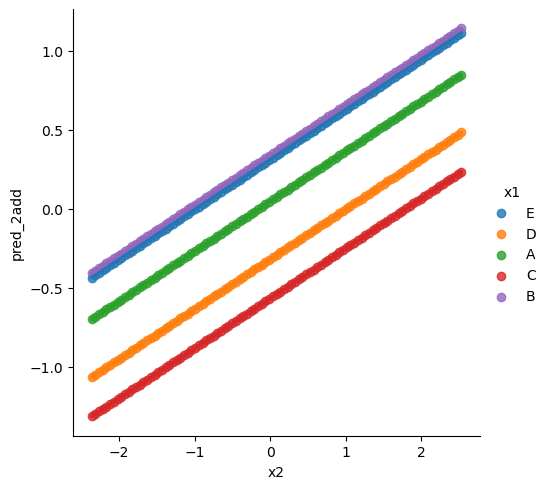

```python
sns.lmplot(data=dfB_viz, x='x2', y='pred_2add', hue='x1')
plt.show()
```

### 8e)

Create the line chart in Seaborn to visualize the predictive trends associated with the **mixed input** model that **interacts** the categorical and numeric inputs.

#### 8e) - SOLUTION

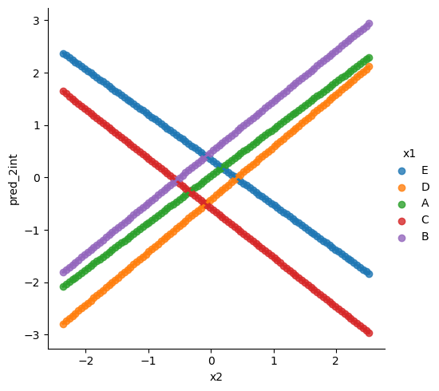

```python
sns.lmplot(data=dfB_viz, x='x2', y='pred_2int', hue='x1')
plt.show()
```

### 8f)

Which of the predictive visualizations is the most consistent with the colored Trend plot from 4g)?

Type your response in a Markdown cell below.

#### 8f) - SOLUTION

The interactive model is the most consistent with the colored Trend plot from 4g)